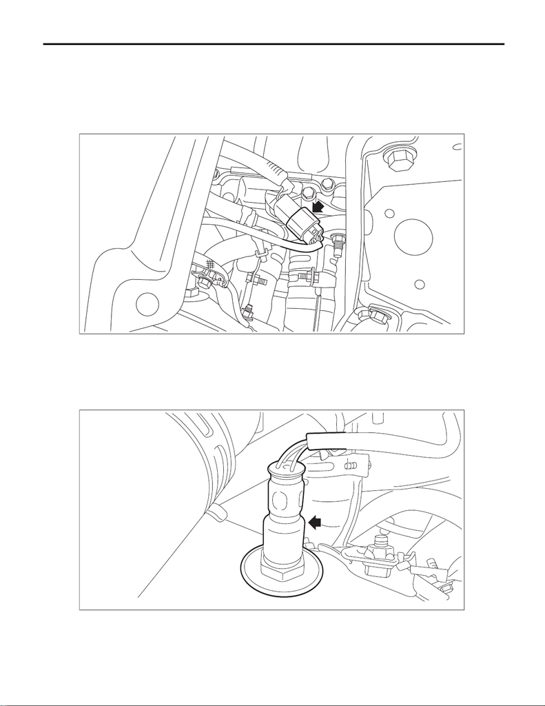

FU(w/o STI)-128

Rear Oxygen Sensor

FUEL INJECTION (FUEL SYSTEMS)

23.Rear Oxygen Sensor

A: REMOVAL

1) Disconnect the ground terminal from battery sensor. <Ref. to NT-5, BATTERY, NOTE, Note.>

2) Lift up the vehicle.

3) Remove the under cover. <Ref. to EI-21, REMOVAL, Front Under Cover.>

4) Disconnect the connector on the rear oxygen sensor from the engine harness.

6) Remove the rear oxygen sensor.

CAUTION:

FU-08375

FU-08372

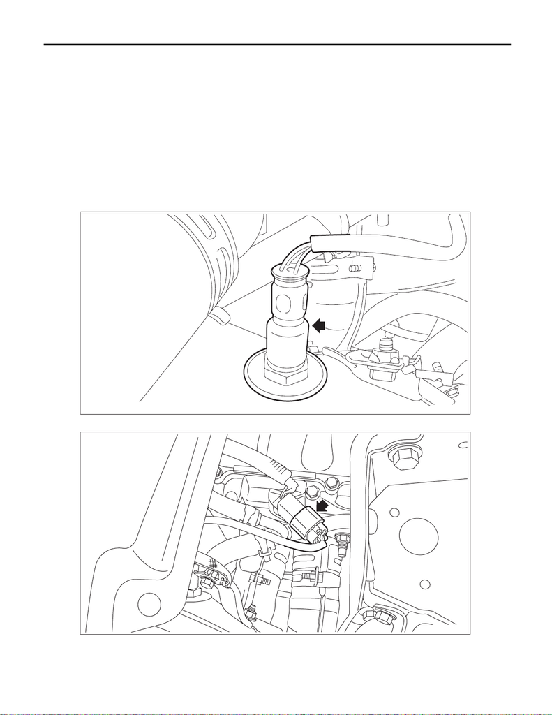

FU(w/o STI)-129

Rear Oxygen Sensor

FUEL INJECTION (FUEL SYSTEMS)

B: INSTALLATION

CAUTION:

CAUTION:

Never apply anti-seize compound to the protector of rear oxygen sensor.

Anti-seize compound:

NEVER-SEEZ NSN, JET LUBE SS-30 or equivalent

2) Install the rear oxygen sensor.

Tightening torque:

21 N·m (2.1 kgf-m, 15.5 ft-lb)

3) Connect the rear oxygen sensor connector to the engine harness.

4) Install the under cover. <Ref. to EI-22, INSTALLATION, Front Under Cover.>

5) Lower the vehicle.

6) Connect the ground terminal to battery sensor. <Ref. to NT-5, BATTERY, NOTE, Note.>

FU-08372

FU-08375

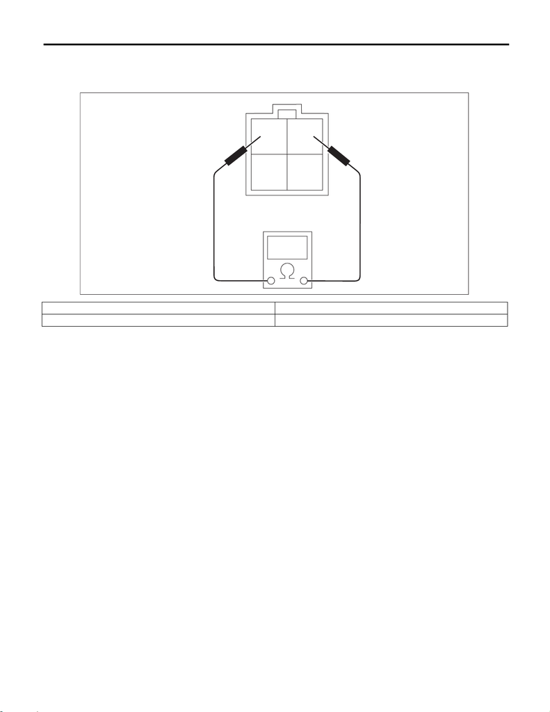

FU(w/o STI)-130

Rear Oxygen Sensor

FUEL INJECTION (FUEL SYSTEMS)

C: INSPECTION

1) Check that the rear oxygen sensor has no deformation, cracks or other damages.

2) Measure the resistance between rear oxygen sensor terminals.

Terminal No. Standard

Ω (when 20°C (68°F))

FU-05962